# Using the ggmcmc package

Xavier Fernández-i-Marín

10/02/2021 - Version 1.5.1.1

Abstract

ggmcmc is an R package for analyzing Markov chain Monte Carlo simulations from Bayesian inference. By using a well known example of hierarchical / multilevel modelling, the document reviews the potential uses and options of the package, which ranges from classical convergence tests to caterpillar plots or posterior predictive checks.

# Why ggmcmc?

`ggplot2`, based on the grammar of graphics (Wilkinson et al. 2005), empowers `R` users by allowing them to flexibly crate graphics (Wickham 2009). Based on this idea, `ggmcmc` is aimed at bringing the design and implementation of `ggplot2` to MCMC diagnostics, allowing Bayesian inference users to have better and more flexible visual diagnostic tools.

`ggplot2` is based on the idea that the input of any graphic is a data frame mapped to aesthetic attributes (colour, size) of geometric objects (points, lines). Therefore, in order to create a graphic the three components must be supplied: a data frame, at least one aesthetic attribute and at least one geometric object. The flexibility comes from the fact that it is very easy to extend basic graphics by including more aesthetic elements and geometric objects, and even faceting the figure to generate the same plot for different subsets of the dataset (Wickham 2009, 3).

The implementation of `ggmcmc` follows this scheme and is based on a function (`ggs()`) that transforms the original input (time series of sampled values for different parameters and chains) into a data frame that is used for all the graphing functions. The plotting functions do any necessary transformation to the samples and return a `ggplot` object, which can be plotted directly into the working device or simply stored as an object, as any other `ggplot` object. Finally, getting `ggplot` objects as the output of the plotting functions has also a positive effect: while the defaults in `ggmcmc` have been carefully chosen, the user later can tweak any graph by—following the ideas of the grammar of graphics—adding other geometric figures, layers of data, contextual information (titles, axis) or applying themes.

So, to sum up, the implementation is driven by the following steps:

1. Convert any input into a data frame using `ggs()`, producing a tidy object (Wickham 2014).
2. Make all plotting functions (`ggs_*())` work with the `ggs` object and produce a `ggplot` object.
3. Let the user post-process the resulting default `ggplot` object.

`ggmcmc` aims also to provide functions to inspect batches of parameters in hierarchical models, to do posterior predictive checks and other model fit figures.

# Importing MCMC samples into ggmcmc using ggs()

```r
library(ggmcmc)
data(radon)
s.radon.short <- radon$s.radon.short
```

The `s.radon.short` object is right now a list of arrays of an `mcmc` class. Each element in the list is a chain, and each matrix is defined by the number of iterations (rows) and the number of parameters (columns). In order to work with `ggplot2` and to follow the rules of the grammar of graphics, data must be converted into a data frame. This is achieved by using the `ggs()` function.

```r
S <- ggs(s.radon.short)
```

`ggs()` produces a data frame object with four variables, namely:

- **Iteration** Number of iteration.
- **Chain** Number of the chain.
- **Parameter** Name of the parameter.
- **value** value sampled.

More specifically, `ggs()` produces a data frame tbl, which is a wrapper in `dplyr` that improves printing data frames. In this case, calling the object produces a compact view of its contents.

```r
S
```

```
## # A tibble: 16,000 x 4
##    Iteration Chain Parameter value
##        <int> <int> <fct>     <dbl>
##  1         1     1 alpha[1]  1.97
##  2         2     1 alpha[1]  1.06
##  3         3     1 alpha[1]  1.17
##  4         4     1 alpha[1]  1.26
##  5         5     1 alpha[1]  1.04
##  6         6     1 alpha[1]  1.71
##  7         7     1 alpha[1]  1.09
##  8         8     1 alpha[1]  0.804
##  9         9     1 alpha[1]  0.823
## 10        10     1 alpha[1]  1.13
## # … with 15,990 more rows
```

A `ggs` object is generally around twice the size of a `mcmc` object (list of matrices), because the iteration number, the number of the chain and the name of the parameter are stored in the resulting object in a less compact way than in `mcmc`. But this duplication of information gives much more flexibility to the package, in the sense that the transformation is done only once and then the resulting object is suitable and ready for the rest of the plotting functions. In other words, the resulting object is in a tidy format (Wickham 2014).

In addition to producing a data frame, `ggs()` also stores some attributes into the data frame, which will be later used by the rest of the functions. This speeds up the package in the sense that avoids the rest of the functions to calculate several items necessary for processing the samples, because it is done in the main `ggs()` function.

```r
str(S)
```

```
## tibble [16,000 × 4] (S3: tbl_df/tbl/data.frame)
##  $ Iteration: int [1:16000] 1 2 3 4 5 6 7 8 9 10 ...
##  $ Chain    : int [1:16000] 1 1 1 1 1 1 1 1 1 1 ...
##  $ Parameter: Factor w/ 4 levels "alpha[1]","alpha[2]",..: 1 1 1 1 1 1 1 1 1 1 ...
##  $ value    : num [1:16000] 1.97 1.06 1.17 1.26 1.04 ...
##  - attr(*, "nChains")= int 2
##  - attr(*, "nParameters")= int 4
##  - attr(*, "nIterations")= int 2000
##  - attr(*, "nBurnin")= num 12000
##  - attr(*, "nThin")= num 10
##  - attr(*, "description")= chr "s.radon.short"
```

In addition to `JAGS` output mentioned above, `ggs()` is capable to automatically incorporate MCMC outputs from several sources:

- **`JAGS`** which produces objects of class `mcmc.list` (Plummer 2013).
- **`MCMCpack`** which produces objects of class `mcmc` (Martin, Quinn, and Park 2011).
- **`rstan`**, **`rstanarm`** and **`brms`** which produce, respectively, objects of classes `stanfit` (Stan Development Team 2013), `stanreg` (Goodrich et al. 2018) and `brmsfit` (Buerkner 2016).
- **`Stan` running alone** when `Stan` runs from the command line it produces csv files (Stan Development Team 2013).

# Using ggmcmc()

`ggmcmc()` is a wrapper to several plotting functions that allows to create very easily a report of the diagnostics in a single PDF or HTML file. This output can then be used to inspect the results more comfortably than using the plots that appear in the screen.

```r
ggmcmc(S)
```

By default, `ggmcmc()` produces a file called `ggmcmc-output.pdf` with 5 parameters in each page, although those default values can be easily changed.

```r
ggmcmc(S, file="model_simple-diag.pdf", param_page=2)
```

It is also possible to specify `NULL` as a filename, and this allows the user to control the device. So it is possible to combine other plots by first opening a PDF device (`pdf(file="new.pdf")`), send other plots and the `ggmcmc(S, file=NULL)` call, and finally close the device (`dev.off()`).

It is also possible to ask `ggmcmc()` to dump only one or some of the plots, using their names as in the functions, without `ggs_`. This option can also be used to dump only one type of plots and get the advantage of having multiple pages in the output.

```r
ggmcmc(S, plot=c("density", "running", "caterpillar"))
```

An HTML report can be obtained by using a filename with HTML extension. By default the HTML report contains PNG figures, but vectorial SVG can also be obtained by using the `dev_type_html` argument. The following code will generate an HTML report with SVG figures.

```r
ggmcmc(S, file = "model_simple.html", dev_type_html = "svg")
```

# Using individual functions

This section presents the functions that can be used mainly for purposes of convergence and substantial interpretation.

## Histograms

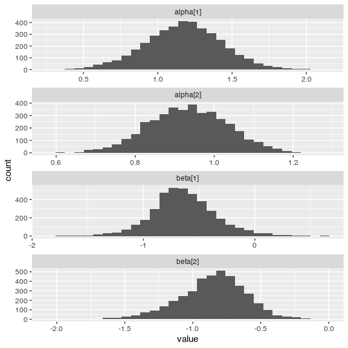

Histogram (ggs_histogram())

```r
ggs_histogram(S)
```

The figure combines the values of all the chains. Although it is not specifically a convergence plot, it is useful for providing a quick look on the distribution of the values and the shape of the posterior distribution.

## Density plots

```r
ggs_density(S)
```

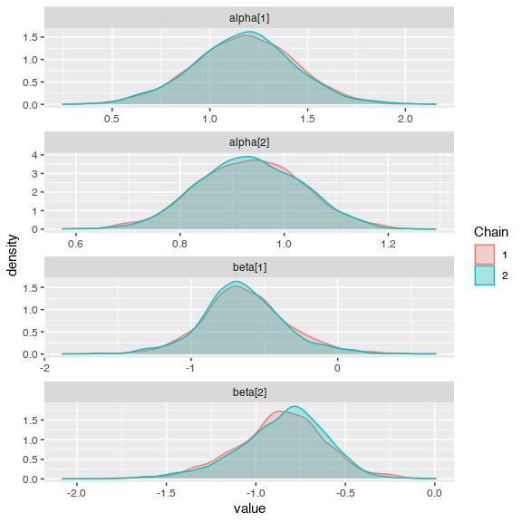

Density plots (ggs_density())

`ggs_density()` produces overlapped density plots with different colors by chain, which allows comparing the target distribution by chains and whether each chain has converged in a similar space.

## Traceplots

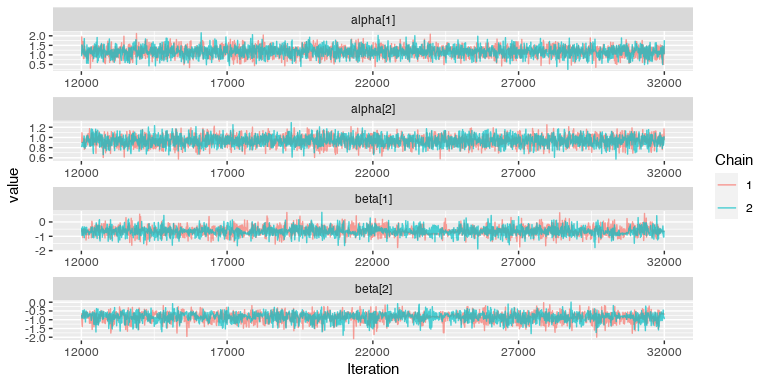

Traceplots (ggs_traceplot())

```r
ggs_traceplot(S)
```

A traceplot is an essential plot for assessing convergence and diagnosing chain problems. It basically shows the time series of the sampling process and the expected outcome is to produce “white noise”. Besides being a good tool to assess within-chain convergence, the fact that different colors are employed for each of the chains facilitates the comparison between chains.

## Running means

```r
ggs_running(S)
```

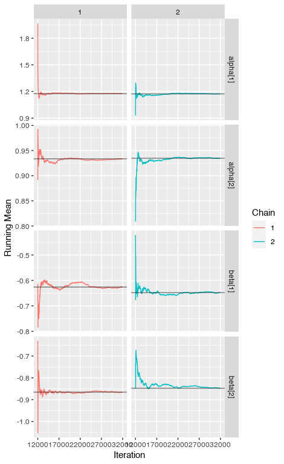

Running means (ggs_running())

A time series of the running mean of the chain is obtained by `ggs_running()`, and allows to check whether the chain is slowly or quickly approaching its target distribution. A horizontal line with the mean of the chain facilitates the comparison. Using the same scale in the vertical axis also allows comparing convergence between chains. The expected output is a line that quickly approaches the overall mean, in addition to the fact that all chains are expected to have the same mean (which is easily assessed through the comparison of the horizontal lines).

## Comparison of the whole chain with the latest part

```r
ggs_compare_partial(S)
```

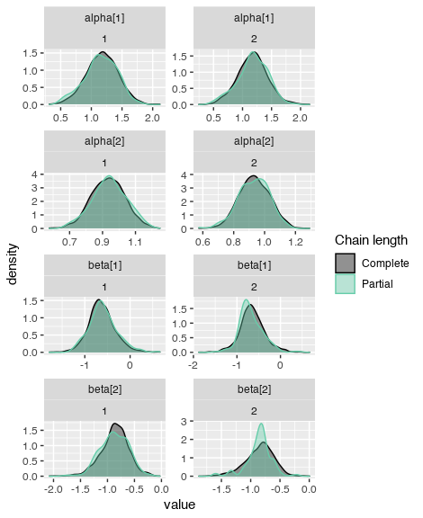

Comparison of the whole chain with the latest part (ggs_compare_partial())

Based on the idea of overlapping densities, `ggs_compare_partial()` produces overlapped density plots that compare the last part of the chain (by default, the last 10 percent of the values, in green) with the whole chain (black). Ideally, the initial and final parts of the chain have to be sampling in the same target distribution, so the overlapped densities should be similar. Notice that the overlapping densities belong to the same chain, therefore the different columns of the plot refer to the different chains.

## Autocorrelation plots

```r
ggs_autocorrelation(S)
```

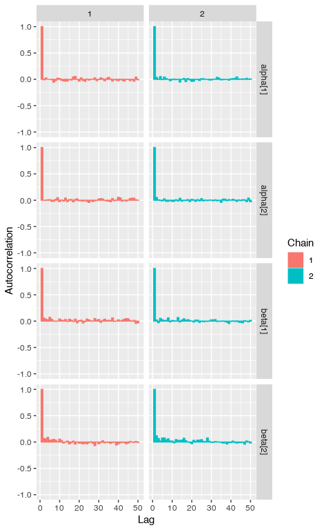

Autocorrelation (ggs_autocorrelation())

The autocorrelation plot expectes a bar at one in the first lag, but no autocorrelation beyond it. While autocorrelation is not *per se* a signal of lack of convergence, it may indicate some misbehaviour of several chains or parameters, or indicate that a chain needs more time to converge. The easiest way to solve issues with autocorrelation is by thinning the chain. The thinning interval can be very easily extracted from the autocorrelation plot.

By default, the autocorrelation axis is bounded between -1 and 1, so all subplots are comparable. The argument `nLags` allows to specify the number of lags to plot, which defaults to 50.

## Crosscorrelation plot

```r
ggs_crosscorrelation(S)
```

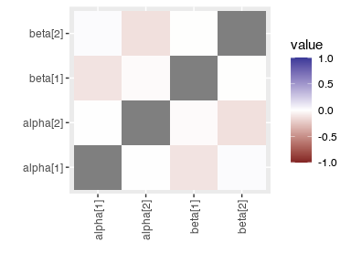

Crosscorrelation (ggs_crosscorrelation())

In order to diagnose potential problems of convergence due to highly correlated parameters, `ggs_crosscorrelation` produces a tile plot with the correlations between all parameters.

The argument `absolute_scale` allows to specify whether the scale must be between -1 and +1. The default is to use an absolute scale, which shows the crosscorrelation problems in overall perspective. But with cases where there is not a severe problem of crosscorrelation between parameters it may help to use relative scales in order to see the most problematic parameters.

## Potential Scale Reduction Factor

```r
ggs_Rhat(S) + xlab("R_hat")
```

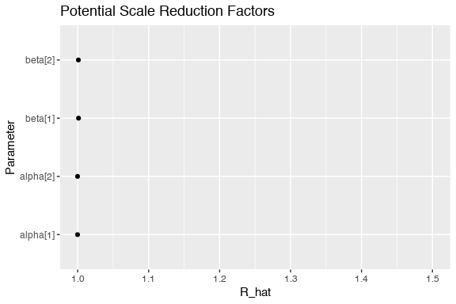

Potential Scale Reduction Factor (ggs_Rhat())

The Potential Scale Reduction Factor ($\hat{R}$)(Gelman et al. 2003) relies on different chains for the same parameter, by comparing the between-chain variation with the within-chain variation. It is expected to be close to 1. The argument `version_Rhat` allows to use the default “BDA2” version ((Gelman et al. 2003)) or the “BG98” version used in the coda package.

## Geweke Diagnostics

```r
ggs_geweke(S)
```

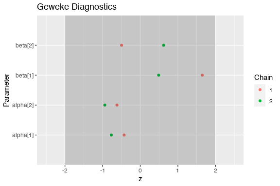

Geweke diagnostic (ggs_geweke())

By contrast the Geweke z-score diagnostic (Geweke 1992) focuses on the comparison of the first part of the chain with its last part. It is in fact a frequentist comparison of means, and the expected outcome is to have 95 percent of the values between -2 and 2. By default, the area between -2 and 2 is shadowed for a quicker inspection of problematic chains.

# Select a family of parametrs

Suppose that the object with the results of a model contains several families of parameters (say, `beta`, `theta`, `sigma`) and that only one of the families you want to use the previous functions but only with one of the families. The argument `family` can then be used to indicate `ggmcmc` to use only certain parameters from the specified family. The following figure shows a density plot similar to a previous one, but with only the parameters that belong to the required family. In this case, all parameters that contain the character string `sigma` will be passed to `ggs_density()`.

The character string provided to `family` can be any regular expression in `R` format. So in cases of having multidimensional arrays of parameters (say, `theta[1,1]` or `theta[10, 5]`), the elements of the first dimension being equal to 4 can be plotted using `family="theta\\[4,.\\]"`.

# Change parameter labels

By default, `ggs` objects use the parameter names provided by the MCMC software. But it is possible to change it when treating the samples with the `ggs()` function using the argument `par_labels`. `par_labels` requires a data frame with at least two columns. One named *Parameter* with the corresponding names of the parameters that are to be changed and another named *Label* with the new parameter labels.

```r
P <- data.frame(
  Parameter=c("sigma.alpha", "sigma.beta", "sigma.y"),
  Label=c("Intercept (sd)", "Covariate (sd)", "Outcome (sd)"))
ggs_density(ggs(radon$s.radon, par_labels=P, family="sigma"))
```

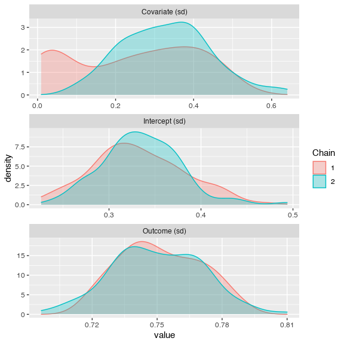

Labels of the parameter names are changed by argument par_labels.

The combination of the arguments `family` and `par_labels` allows to have high control in terms of flexibility (which parameters are shown, using `family`) as well as in terms of substantial interpretation (the labels attached to each parameter, using `par_labels`). However, it must be noticed that selecting a family of parameters can be done either when converting the output of the MCMC software using the `ggs()` function, or inside the `ggs_*()` individual functions. But using the `par_labels` argument is only done through the `ggs()` call.

# Caterpillar plots

Caterpillar plots provide a very flexible graphical solution to interpret substantial results from Bayesian analysis, specially when dealing with lots of parameters, as is usually the case with hierarchical / multilevel models.

The simplest use is to get a sense of the distribution of the parameters, using their name as a label. The function produces caterpillar plots of the highest posterior densities of the parameters. By default, `ggs_caterpillar()` produces thick lines at the 90% highest posterior density (HPD) region and thin lines at the 95% HPD.

In this case, in order to create a matching data frame for parameters and labels, `ggmcmc` contains a function that performs this function, and is specially suitable when multi-dimensional parameters are used. This is the case of hierarchical/multilevel models and parameters that contain subscripts by *i* (observations), *j* (groups), *t* (time), etc… `plab()` needs two arguments. The first one is the name of the parameter, which in this case is `alpha`. The second argument is a named list containing all the values that refer to the subscripts of the parameter. The following use of `plab()` creates a data set with the matches between the parameter names for the intercepts (`alpha[1]:alpha[85]`) and their substantial meaning (labels for counties) and then it passes this data frame as an argument to the `ggs()` function that converts the original samples in `JAGS` into a proper object ready for being used by all `ggs_*()` functions.

```r
L.radon.intercepts <- plab("alpha", list(County = radon$counties$County))
head(L.radon.intercepts)
```

```
## # A tibble: 6 x 4
##   dim.1 Parameter County   Label
##   <int> <fct>     <fct>    <fct>
## 1     1 alpha[1]  Aitkin   Aitkin
## 2     2 alpha[2]  Anoka    Anoka
## 3     3 alpha[3]  Becker   Becker
## 4     4 alpha[4]  Beltrami Beltrami
## 5     5 alpha[5]  Benton   Benton
## 6     6 alpha[6]  Bigstone Bigstone
```

```r
S.full <- ggs(radon$s.radon, par_labels=L.radon.intercepts, family="^alpha")
```

```r
ggs_caterpillar(S.full)
```

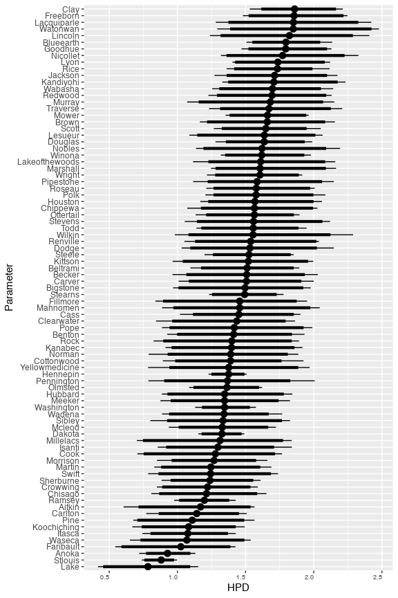

Caterpillar plot (ggs_caterpillar()).

`ggs_caterpillar()` can also be used to plot against continuous variables. The use of this feature may be very useful when plotting the varying slopes or intercepts of several groups in multilevel modelling against a continuous feature of such groups.

This can be achieved by passing a data frame (`X`) with two columns. One column with the `Parameter` name and the other with its `value`. Notice that when used against a continuous variable it is more convenient to use vertical lines instead of the default horizontal lines.

```r
Z <- data.frame(
  Parameter=paste("alpha[", radon$counties$id.county, "]", sep=""),
  value=radon$counties$uranium)
ggs_caterpillar(ggs(radon$s.radon, family="^alpha"), X=Z, horizontal=FALSE)
```

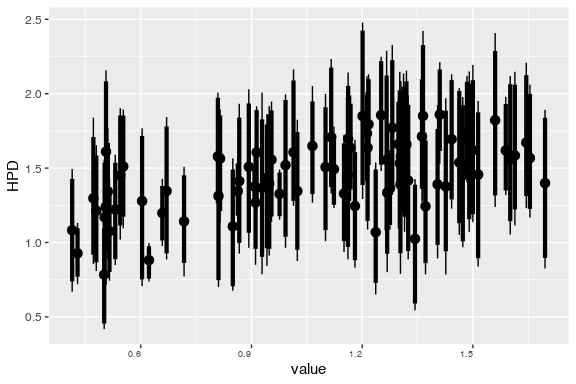

Caterpillar plot against a continuous variable.

Another feature of caterpillar plots is the possibility to plot two different models, and be able to easily compare between them. A list of two `ggs()` objects must be provided.

The `ci()` function that calculates the credible intervals in the caterpillar plots can also be used outside the graphical display, generating a `tbl_df` suitable for other analysis.

```r
ci(S)
```

```
## # A tibble: 4 x 6
##   Parameter    low    Low median   High     high
##   <fct>      <dbl>  <dbl>  <dbl>  <dbl>    <dbl>
## 1 alpha[1]   0.650  0.738  1.18   1.60   1.68
## 2 alpha[2]   0.737  0.773  0.934  1.10   1.13
## 3 beta[1]   -1.21  -1.09  -0.654 -0.125 -0.00518
## 4 beta[2]   -1.42  -1.31  -0.835 -0.480 -0.404
```

# Posterior predictive checks and model fit

`ggmcmc` incorporates several functions to check model fit and perform posterior predictive checks. As to the current version, only outcomes in uni-dimensional vectors are allowed.

The outcomes can be continuous or binary, and different functions take care of them. The main input for the functions is also a `ggs` object, but in this case it must only contain the predicted values. $\hat{y}_{i}$ are the expected values in the context of the radon example. They can also be sampled and converted into a `ggs` object using the argument `family`.

In order to illustrate posterior predictive checks, samples from a faked dataset will be used. `ggmcmc` contains samples from a linear model with an intercept and a covariate (object `s`), where `y.rep` are posterior predictive samples from a dataset replicated from the original, but without the original outcome ($y$).

```r
data(linear) # brings 's.y.rep', 'y' and 's'
S.y.rep <- ggs(s.y.rep)
y.observed <- y
```

## Continuous outcomes

For continuous outcomes, `ggs_ppmean()` (posterior predictive means) presents a histogram with the means of the posterior predictive values at each iteration, and a vertical line showing the location of the sample mean.

```r
ggs_ppmean(S.y.rep, outcome=y.observed)
```

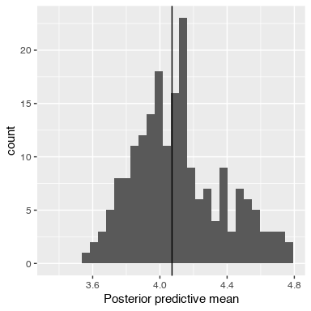

This allows comparing the sample mean with the means of the posterior and check if there are substantial deviances.

`ggs_ppsd()` (posterior predictive standard deviations) presents the same idea as `ggs_ppmean()` but in this case using the posterior standard deviations.

```r
ggs_ppsd(S.y.rep, outcome=y.observed)
```

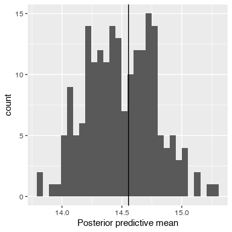

Posterior predictive standard deviations against the sample standard deviation (ggs_ppsd()).

## Binary outcomes

In order to illustrate the functions suitable for binary outcomes a new dataset must be simulated, and samples of parameters from a simple logistic regression model must be obtained. `ggmcmc` also contains samples from such a model, in the dataset `data(binary)`. Again, arrange the samples as a `ggs` object

```r
data(binary)
S.binary <- ggs(s.binary, family="mu")
```

The ROC (receiver operating characteristic) plot presents a ROC curve.

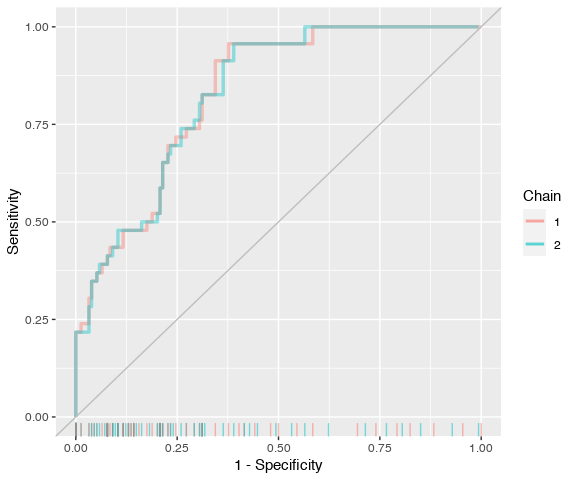

ROC (receiver operating characteristic) curve.

```r
ggs_rocplot(S.binary, outcome=y.binary)
```

The `ggs_rocplot()` is not fully Bayesian by default. This means that the predicted probabilities by observation are reduced to their median values across iterations from the beginning. Only information relative to the chain is kept. If a fully Bayesian version is desired, the argument `fully_bayesian=TRUE` has to be set up. But use it with care, because it is very demanding in terms of CPU and memory.

```r
ggs_separation(S.binary, outcome=y.binary)
```

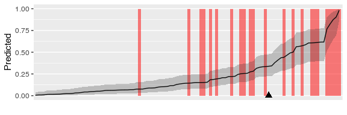

Separation plot.

The arguments `show_labels` (FALSE by default) and `uncertainty_band` (TRUE by default) allow to control, respectively, whether the Parameter names will be displayed and whether the uncertainty of the predicted values will be shown.

```r
ggs_separation(S.binary, outcome=y.binary,
  show_labels = TRUE, uncertainty_band = FALSE)
```

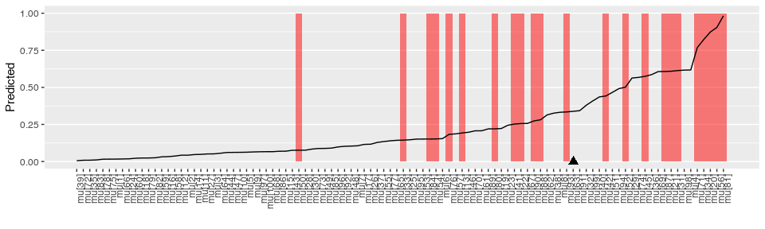

Separation plot with parameter labels and without uncertainty band on the predicted values.

The argument `minimalist` (FALSE by default) allows get a minimal Tufte style inline version of the separation plot.

```r
ggs_separation(S.binary, outcome=y.binary, minimalist = TRUE)
```

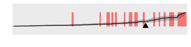

Separation plot (minimalist version).

## Percent of correctly predicted

The distribution of the percentage of correctly predicted cases can be obtained using the `ggs_pcp()` function:

```r
ggs_pcp(S.binary, outcome=y.binary)
```

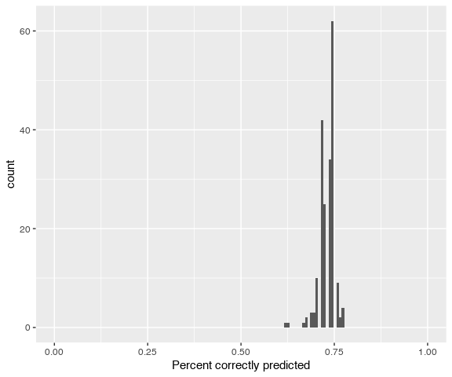

Distribution of the percentage of cases correctly predicted.

# Paired plots

The package `ggally` provides an easy way to extend `ggmcmc` through the `ggs_pairs()` function, which by defaults shows the scatterplots of the pairs of parameters in the `ggs` object, the densities and the crosscorrelations in a single layout. In the following example, the `lower` argument to `ggs_pairs()` is passed to `ggpairs()` as a list so that the figures in the lower quadrant are not scatterplots, but contours instead.

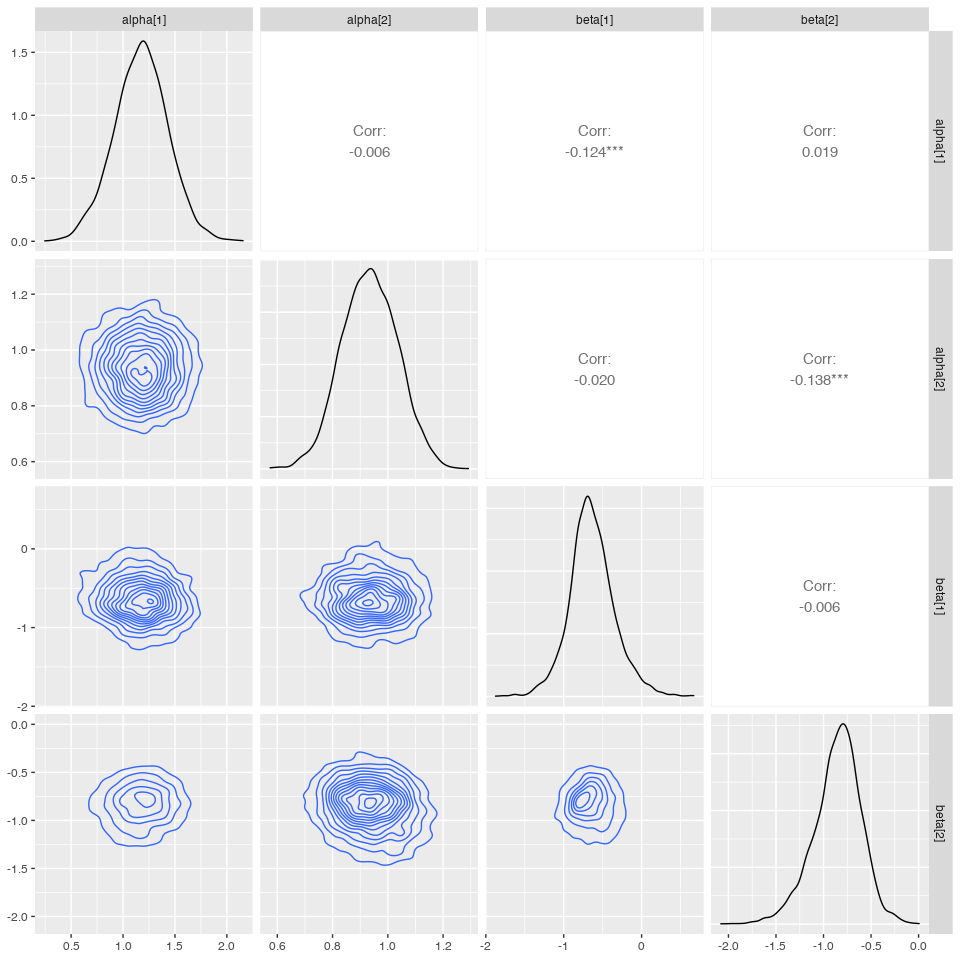

```r
ggs_pairs(S, lower = list(continuous = "density"))
```

# Greek letters

In Bayesian inference it is common to use Greek letters for the parameters, and ggmcmc allows to use the original Greek letters instead of their names in English, by using the `greek = TRUE` parameter in all the functions. Then, a repetition of the histogram using Greek letters can be obtained by:

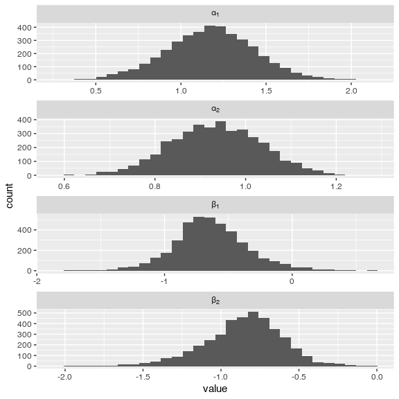

Histogram (ggs_histogram()) with parameter names using Greek letters.

```r
ggs_histogram(S, greek = TRUE)
```

# Aesthetic variations

The combination of `ggmcmc` with the package `ggthemes` allows using pre-specified `ggplot2` themes, like `theme_tufte` (that is based on a minimal ink principle by (Tufte and Graves-Morris 1983), `theme_economist` (that replicates the aesthetic appearance of *The Economist* magazine), or `thema_stata` (that produces `Stata` graph schemes), amongst others.

In addition to `ggthemes`, `ggmcmc` can also work well with `gridExtra`, a package that allows combining several `ggplot` objects in a single layout.

# Combination with the power of ggplot2

The philosophy of `ggmcmc` is not to provide all the flexibility of `ggplot2` hard-coded in the functions. Instead, the idea is to provide a flexible environment to treat `ggs` objects in a basic way and then move back to all the potential that `ggplot2` offers.

One facility is to extend `ggs_caterpillar()` using facets with variables passed through `par_labels`, or adding other variables to the aesthetics. The following figure shows a caterpillar plot of the intercepts, with facets on the North/South location and using a color scale to emphasize the uranium level by county.

```r
ci.median <- ci(ggs(radon$s.radon, family = "^alpha|^beta")) %>%
  select(Parameter, median)

L.radon <- bind_rows(
   plab("alpha", list(County = radon$counties$County)) %>%
     mutate(Coefficient = "Intercept"),
   plab("beta", list(County = radon$counties$County)) %>%
     mutate(Coefficient = "Slope")) %>%
  left_join(radon$counties) %>%
  rename(Uranium = uranium) %>%
  rename(Location = ns.location)
head(L.radon)
```

```
## # A tibble: 6 x 8
##   dim.1 Parameter County   Label    Coefficient id.county Uranium Location
##   <int> <fct>     <chr>    <fct>    <chr>           <dbl>   <dbl> <chr>
## 1     1 alpha[1]  Aitkin   Aitkin   Intercept           1   0.502 North
## 2     2 alpha[2]  Anoka    Anoka    Intercept           2   0.429 South
## 3     3 alpha[3]  Becker   Becker   Intercept           3   0.893 North
## 4     4 alpha[4]  Beltrami Beltrami Intercept           4   0.552 North
## 5     5 alpha[5]  Benton   Benton   Intercept           5   0.867 South
## 6     6 alpha[6]  Bigstone Bigstone Intercept           6   1.47  South
```

```r
ggs_caterpillar(ggs(radon$s.radon, par_labels = L.radon, family = "^alpha")) +
  facet_wrap(~ Location, scales = "free") +
  aes(color = Uranium)
```

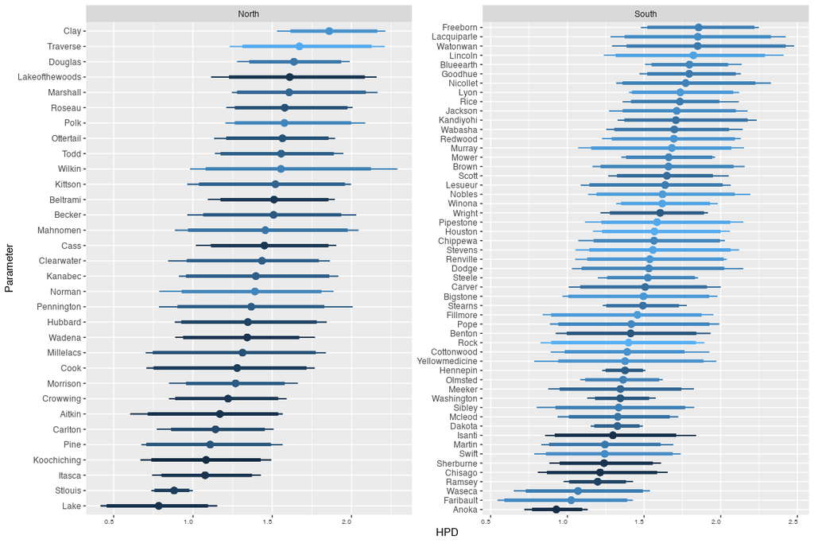

Caterpillar plot of the varying intercepts faceted by North/South location and using county’s uranium level as color indicator.

Another option is, for instance, when the display is not enough to accommodate all parameters, to use `facet_wrap()` to accommodate several parameters in a faceted way, not only vertically (as is the `ggmcmc` default).

```r
ggs_density(ggs(radon$s.radon, par_labels=L.radon, family="^alpha"),
            hpd = TRUE) +
  facet_wrap(~ Parameter, ncol = 6)
```

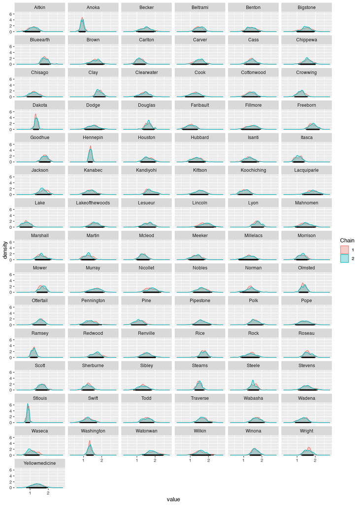

Density plots of the varying intercepts faceted in a grid by columns.

# Development

The development of `ggmcmc` (track changes, propose improvements, report bugs) can be followed at https://github.com/xfim/ggmcmc.

# Acknowledgements

I would like to thank code contributions and ideas from [Zachary M. Jones](http://zmjones.com/), [Julien Cornebise](https://cornebise.com/julien/), [Max Joseph](https://mbjoseph.github.io/), and ideas from [Dieter Menne](https://www.menne-biomed.de/), Bill Dixon, [Christopher Gandrud](http://christophergandrud.blogspot.com), Barret Schloerke and GitHub users knokknok, akrawitz, Justina (Juste), stefanherzog, [Brian Stock](https://github.com/brianstock), [Jonas Kristoffer Lindeløv](https://lindeloev.net/), [Jakob Fiksel](https://github.com/jfiksel), [Sébastien Rochette](https://statnmap.com/) and [Stéphane Guillou](https://github.com/stragu).

# References

Buerkner, Paul-Christian. 2016. *Brms: Bayesian Regression Models Using Stan*. https://CRAN.R-project.org/package=brms.

Gelman, Andrew, John B. Carlin, Hal S. Stern, and Donald B. Rubin. 2003. *Bayesian Data Analysis, Second Edition*. Boca Ratón, FL: Hardcover; Chapman & Hall/CRC.

Geweke, John F. 1992. “Evaluating the Accuracy of Sampling-Based Approaches to the Calculation of Posterior Moments.” In *Bayesian Statistics 4*, edited by J. O. Berger, J. M. Bernardo, A. P. Dawid, and A. F. M. Smith. Oxford, UK: Clarendon Press.

Goodrich, Ben, Jonah Gabry, Imad Ali, and Sam Brilleman. 2018. “Rstanarm: Bayesian Applied Regression Modeling via Stan.” https://mc-stan.org/.

Greenhill, Brian, Michael D Ward, and Audrey Sacks. 2011. “The Separation Plot: A New Visual Method for Evaluating the Fit of Binary Models.” *American Journal of Political Science* 55 (4): 991–1002.

Martin, Andrew D., Kevin M. Quinn, and Jong Hee Park. 2011. “MCMCpack: Markov Chain Monte Carlo in R.” *Journal of Statistical Software* 42 (9): 22. https://www.jstatsoft.org/article/view/v042i09.

Plummer, Martyn. 2013. *JAGS: Just Another Gibbs Sampler*. http://mcmc-jags.sourceforge.net/.

Stan Development Team. 2013. “Stan: A C++ Library for Probability and Sampling, Version 1.3.” https://mc-stan.org/.

Tufte, Edward R, and PR Graves-Morris. 1983. *The Visual Display of Quantitative Information*. Vol. 2. Graphics press Cheshire, CT.

Wickham, Hadley. 2009. *Ggplot2: Elegant Graphics for Data Analysis*. Use R! Springer-Verlag. https://books.google.es/books?id=bes-AAAAQBAJ.

———. 2014. “Tidy Data.” *Under Review*.

Wilkinson, L., D. Wills, D. Rope, A. Norton, and R. Dubbs. 2005. *The Grammar of Graphics*. Statistics and Computing. Springer-Verlag.